# APARICIÓN DE DEPRESIÓN, SUICIDIO, PIB

Repositorio: [GitHub](https://github.com/marinamartinm/Seminario_MEC)

CÉSAR TEJIDO, ELENA RUIZ, MARINA MARTÍN

2023-12-11

# Introduccion

La salud mental en España es cada vez más preocupante, se ha disparado el número de jóvenes que ha tenido problemas de salud mental. En 2017 el primer Barómetro registraba un 28,4% de jóvenes con problemas de salud mental y en 2023 llega al 59,3%.

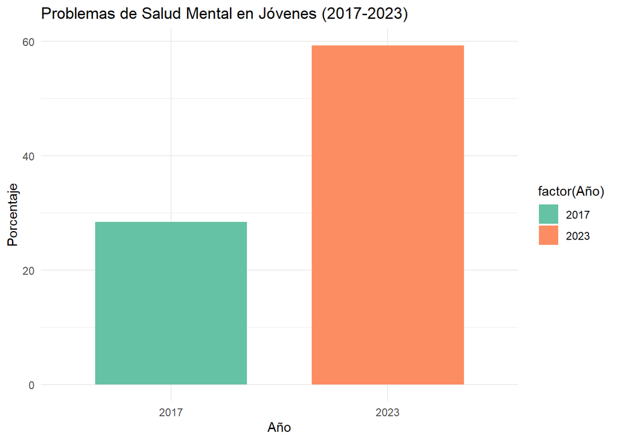

La brecha de género también existe en salud mental. Hay más hombres que mujeres que nunca han experimentado trastornos (42,4%, frente al 30,9% de ellas).

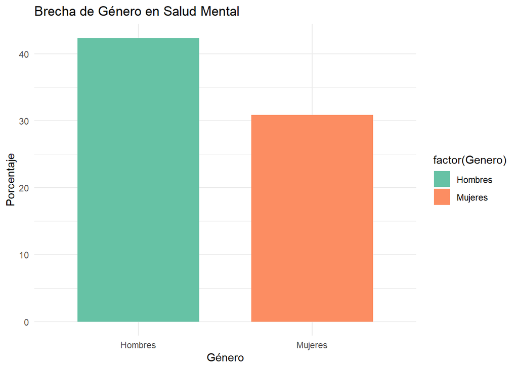

Los datos no son positivos de por sí, pero son aún peores cuando los cruzamos con variables socioeconómicas y corroboramos que la vulnerabilidad frente a enfermedades y trastornos mentales está relacionada con las carencias materiales que se tienen, y también las posibilidades de reducir esa vulnerabilidad.

Los datos de este barómetro en 2023 también evidencian el incremento en la ideación suicida. 1 de cada 4 jóvenes ha experimentado alguna vez ideas suicidas (23,8%), un 11,3% piensa en el suicidio con cierta frecuencia y el 13,8% experimenta ideas de suicidio con mucha frecuencia o continuamente.

[figure not shown]

# Objetivos

- Estudiar la relación entre la aparición de enfermedades mentales frente a diferentes factores y su derivación en el suicidio.
- Averiguar si existe relación entre el PIB con los datos sobre transtornos mentales en España y estudiar si en aquellas comunidades autónomas en las que el PIB sea más bajo tienen influencia sobre la tasa de suicidio de estas.
- Realizar un estudio general con todas las variables para encontrar una posible relación con la tasa de suicidio.

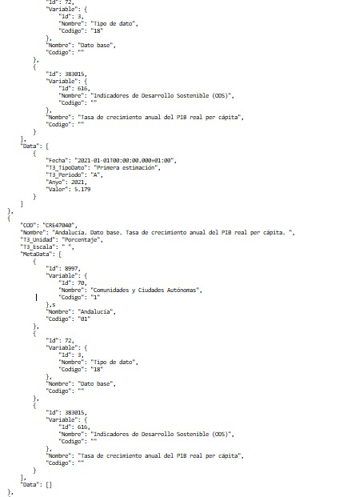

# Datos

- PIB por CCAA: “https://www.ine.es/jaxiT3/Datos.htm?t=45599” (Csv)
- Tasa de suicidio por CCAA: “https://www.ine.es/jaxiT3/Datos.htm?tpx=46688” (Json)
- Depresión por CCAA: “https://datos.gob.es/es/catalogo/ea0010587-prevalencia-de-cuadros-depresivos-activos-segun-sexo-y-comunidad-autonoma-poblacion-de-15-y-mas-anos-identificador-api-t15-p420-a2019-p04-l0-13010-px1” (Json)

Los archivos escogidos pertenecen a dos fuentes de datos: el Instituto Nacional de Estadística (INE) y la página oficial del Gobierno de España (gob.es) El formato de datos escogido son tanto .csv como .json.

## Importación

### 1º Conjunto de datos: Depresión por CCAA

```
## # A tibble: 240 × 4
##    document.id Sexo        Comunidad    Prevalencia
##          <int> <chr>       <chr>        <chr>
##  1           1 Ambos sexos " Total"     " TOTAL"
##  2           2 Ambos sexos " Total"     " Cuadro depresivo mayor"
##  3           3 Ambos sexos " Total"     " Otros cuadros depresivos"
##  4           4 Ambos sexos " Total"     " Sin cuadro depresivo alguno"
##  5           5 Ambos sexos " Andalucía" " TOTAL"
##  6           6 Ambos sexos " Andalucía" " Cuadro depresivo mayor"
##  7           7 Ambos sexos " Andalucía" " Otros cuadros depresivos"
##  8           8 Ambos sexos " Andalucía" " Sin cuadro depresivo alguno"
##  9           9 Ambos sexos " Aragón"    " TOTAL"
## 10          10 Ambos sexos " Aragón"    " Cuadro depresivo mayor"
## # ℹ 230 more rows
```

```
## # A tibble: 3 × 3
##   name     type       n
##   <chr>    <fct>  <int>
## 1 Data     array    240
## 2 MetaData array    240
## 3 Nombre   string   240
```

```
## # A tbl_json: 240 x 3 tibble with a "JSON" attribute
##    ..JSON              document.id  Valor
##    <chr>                     <int>  <dbl>
##  1 "{\"Valor\":100}"             1 100
##  2 "{\"Valor\":2.46}"            2   2.46
##  3 "{\"Valor\":2.9}"             3   2.9
##  4 "{\"Valor\":94.64}"           4  94.6
##  5 "{\"Valor\":100}"             5 100
##  6 "{\"Valor\":2.13}"            6   2.13
##  7 "{\"Valor\":1.75}"            7   1.75
##  8 "{\"Valor\":96.12}"           8  96.1
##  9 "{\"Valor\":100}"             9 100
## 10 "{\"Valor\":1.85}"           10   1.85
## # ℹ 230 more rows
```

```
## # A tibble: 240 × 5
##    document.id Sexo        Comunidad    Prevalencia                     Valor
##          <int> <chr>       <chr>        <chr>                           <dbl>
##  1           1 Ambos sexos " Total"     " TOTAL"                       100
##  2           2 Ambos sexos " Total"     " Cuadro depresivo mayor"        2.46
##  3           3 Ambos sexos " Total"     " Otros cuadros depresivos"      2.9
##  4           4 Ambos sexos " Total"     " Sin cuadro depresivo alguno"  94.6
##  5           5 Ambos sexos " Andalucía" " TOTAL"                       100
##  6           6 Ambos sexos " Andalucía" " Cuadro depresivo mayor"        2.13
##  7           7 Ambos sexos " Andalucía" " Otros cuadros depresivos"      1.75
##  8           8 Ambos sexos " Andalucía" " Sin cuadro depresivo alguno"  96.1
##  9           9 Ambos sexos " Aragón"    " TOTAL"                       100
## 10          10 Ambos sexos " Aragón"    " Cuadro depresivo mayor"        1.85
## # ℹ 230 more rows
```

```
## # A tibble: 240 × 5
##    document.id Sexo_Depresion Comunidad    Prevalencia           Valor_Depresion
##          <int> <chr>          <chr>        <chr>                           <dbl>
##  1           1 Ambos sexos    " Total"     " TOTAL"                       100
##  2           2 Ambos sexos    " Total"     " Cuadro depresivo m…            2.46
##  3           3 Ambos sexos    " Total"     " Otros cuadros depr…            2.9
##  4           4 Ambos sexos    " Total"     " Sin cuadro depresi…           94.6
##  5           5 Ambos sexos    " Andalucía" " TOTAL"                       100
##  6           6 Ambos sexos    " Andalucía" " Cuadro depresivo m…            2.13
##  7           7 Ambos sexos    " Andalucía" " Otros cuadros depr…            1.75
##  8           8 Ambos sexos    " Andalucía" " Sin cuadro depresi…           96.1
##  9           9 Ambos sexos    " Aragón"    " TOTAL"                       100
## 10          10 Ambos sexos    " Aragón"    " Cuadro depresivo m…            1.85
## # ℹ 230 more rows
```

```
##  [1] " Andalucía"                    " Aragón"
##  [3] " Asturias (Principado de)"     " Balears (Illes)"
##  [5] " Canarias"                     " Cantabria"
##  [7] " Castilla-La Mancha"           " Castilla y León"
##  [9] " Cataluña"                     " Ceuta (Ciudad Autónoma de)"
## [11] " Comunitat Valenciana"         " Extremadura"
## [13] " Galicia"                      " Madrid (Comunidad de)"
## [15] " Melilla (Ciudad Autónoma de)" " Murcia (Región de)"
## [17] " Navarra (Comunidad Foral de)" " País Vasco"
## [19] " Rioja (La)"                   " Total"
```

```
## # A tibble: 240 × 5
##    document.id Sexo_Depresion Prevalencia              Valor_Depresion Comunidad
##          <int> <chr>          <chr>                              <dbl> <chr>
##  1           1 Ambos sexos    " TOTAL"                          100    Total na…
##  2           2 Ambos sexos    " Cuadro depresivo mayo…            2.46 Total na…
##  3           3 Ambos sexos    " Otros cuadros depresi…            2.9  Total na…
##  4           4 Ambos sexos    " Sin cuadro depresivo …           94.6  Total na…
##  5           5 Ambos sexos    " TOTAL"                          100    Andalucía
##  6           6 Ambos sexos    " Cuadro depresivo mayo…            2.13 Andalucía
##  7           7 Ambos sexos    " Otros cuadros depresi…            1.75 Andalucía
##  8           8 Ambos sexos    " Sin cuadro depresivo …           96.1  Andalucía
##  9           9 Ambos sexos    " TOTAL"                          100    Aragón
## 10          10 Ambos sexos    " Cuadro depresivo mayo…            1.85 Aragón
## # ℹ 230 more rows
```

### 2º Conjunto de datos: PIB por CCAA

```
## # A tbl_json: 20 x 6 tibble with a "JSON" attribute
##    ..JSON                  document.id COD      Nombre       T3_Unidad T3_Escala
##    <chr>                         <int> <chr>    <chr>        <chr>     <chr>
##  1 "{\"COD\":\"CRE4704..."           1 CRE47041 "Total Naci… Porcenta… " "
##  2 "{\"COD\":\"CRE4704..."           2 CRE47040 "Andalucía.… Porcenta… " "
##  3 "{\"COD\":\"CRE4703..."           3 CRE47039 "Aragón. Da… Porcenta… " "
##  4 "{\"COD\":\"CRE4703..."           4 CRE47038 "Asturias, … Porcenta… " "
##  5 "{\"COD\":\"CRE4703..."           5 CRE47037 "Balears, I… Porcenta… " "
##  6 "{\"COD\":\"CRE4703..."           6 CRE47036 "Canarias. … Porcenta… " "
##  7 "{\"COD\":\"CRE4703..."           7 CRE47035 "Cantabria.… Porcenta… " "
##  8 "{\"COD\":\"CRE4703..."           8 CRE47034 "Castilla y… Porcenta… " "
##  9 "{\"COD\":\"CRE4703..."           9 CRE47033 "Castilla -… Porcenta… " "
## 10 "{\"COD\":\"CRE4703..."          10 CRE47032 "Cataluña. … Porcenta… " "
## 11 "{\"COD\":\"CRE4703..."          11 CRE47031 "Comunitat … Porcenta… " "
## 12 "{\"COD\":\"CRE4703..."          12 CRE47030 "Extremadur… Porcenta… " "
## 13 "{\"COD\":\"CRE4702..."          13 CRE47029 "Galicia. D… Porcenta… " "
## 14 "{\"COD\":\"CRE4702..."          14 CRE47028 "Madrid, Co… Porcenta… " "
## 15 "{\"COD\":\"CRE4702..."          15 CRE47027 "Murcia, Re… Porcenta… " "
## 16 "{\"COD\":\"CRE4702..."          16 CRE47026 "Navarra, C… Porcenta… " "
## 17 "{\"COD\":\"CRE4702..."          17 CRE47025 "País Vasco… Porcenta… " "
## 18 "{\"COD\":\"CRE4702..."          18 CRE47024 "Rioja, La.… Porcenta… " "
## 19 "{\"COD\":\"CRE4702..."          19 CRE47023 "Ceuta. Dat… Porcenta… " "
## 20 "{\"COD\":\"CRE4702..."          20 CRE47022 "Melilla. D… Porcenta… " "
```

```
## # A tibble: 20 × 2
##    document.id Comunidad
##          <int> <chr>
##  1           1 Tota
##  2           2 Andalucía
##  3           3 Aragón
##  4           4 Asturias
##  5           5 Balears
##  6           6 Canarias
##  7           7 Cantabria
##  8           8 Castill
##  9           9 Castill
## 10          10 Cataluña
## 11          11 Comunita
## 12          12 Extremadura
## 13          13 Galicia
## 14          14 Madrid
## 15          15 Murcia
## 16          16 Navarra
## 17          17 Paí
## 18          18 Rioja
## 19          19 Ceuta
## 20          20 Melilla
```

```
## # A tibble: 6 × 3
##   name      type       n
##   <chr>     <fct>  <int>
## 1 COD       string    20
## 2 Data      array     20
## 3 MetaData  array     20
## 4 Nombre    string    20
## 5 T3_Escala string    20
## 6 T3_Unidad string    20
```

```
## # A tbl_json: 60 x 13 tibble with a "JSON" attribute
##    ..JSON        document.id COD   Nombre T3_Unidad T3_Escala array.index     Id
##    <chr>               <int> <chr> <chr>  <chr>     <chr>           <int>  <dbl>
##  1 "{\"Id\":164…           1 CRE4… "Tota… Porcenta… " "                 1  16473
##  2 "{\"Id\":72,…           1 CRE4… "Tota… Porcenta… " "                 2     72
##  3 "{\"Id\":383…           1 CRE4… "Tota… Porcenta… " "                 3 383015
##  4 "{\"Id\":899…           2 CRE4… "Anda… Porcenta… " "                 1   8997
##  5 "{\"Id\":72,…           2 CRE4… "Anda… Porcenta… " "                 2     72
##  6 "{\"Id\":383…           2 CRE4… "Anda… Porcenta… " "                 3 383015
##  7 "{\"Id\":899…           3 CRE4… "Arag… Porcenta… " "                 1   8998
##  8 "{\"Id\":72,…           3 CRE4… "Arag… Porcenta… " "                 2     72
##  9 "{\"Id\":383…           3 CRE4… "Arag… Porcenta… " "                 3 383015
## 10 "{\"Id\":899…           4 CRE4… "Astu… Porcenta… " "                 1   8999
## # ℹ 50 more rows
## # ℹ 5 more variables: Nombre.2 <chr>, Codigo <chr>, Variable.Id <dbl>,
## #   Variable.Nombre <chr>, Variable.Codigo <chr>
```

```
## # A tibble: 20 × 12
##    document.id COD      Nombre T3_Unidad T3_Escala array.index Fecha T3_TipoDato
##          <int> <chr>    <chr>  <chr>     <chr>           <int> <chr> <chr>
##  1           1 CRE47041 "Tota… Porcenta… " "                 1 2021… Primera es…
##  2           2 <NA>      <NA>  <NA>      <NA>               NA <NA>  <NA>
##  3           3 <NA>      <NA>  <NA>      <NA>               NA <NA>  <NA>
##  4           4 <NA>      <NA>  <NA>      <NA>               NA <NA>  <NA>
##  5           5 <NA>      <NA>  <NA>      <NA>               NA <NA>  <NA>
##  6           6 <NA>      <NA>  <NA>      <NA>               NA <NA>  <NA>
##  7           7 <NA>      <NA>  <NA>      <NA>               NA <NA>  <NA>
##  8           8 <NA>      <NA>  <NA>      <NA>               NA <NA>  <NA>
##  9           9 <NA>      <NA>  <NA>      <NA>               NA <NA>  <NA>
## 10          10 <NA>      <NA>  <NA>      <NA>               NA <NA>  <NA>
## 11          11 <NA>      <NA>  <NA>      <NA>               NA <NA>  <NA>
## 12          12 <NA>      <NA>  <NA>      <NA>               NA <NA>  <NA>
## 13          13 <NA>      <NA>  <NA>      <NA>               NA <NA>  <NA>
## 14          14 <NA>      <NA>  <NA>      <NA>               NA <NA>  <NA>
## 15          15 <NA>      <NA>  <NA>      <NA>               NA <NA>  <NA>
## 16          16 <NA>      <NA>  <NA>      <NA>               NA <NA>  <NA>
## 17          17 <NA>      <NA>  <NA>      <NA>               NA <NA>  <NA>
## 18          18 <NA>      <NA>  <NA>      <NA>               NA <NA>  <NA>
## 19          19 <NA>      <NA>  <NA>      <NA>               NA <NA>  <NA>
## 20          20 <NA>      <NA>  <NA>      <NA>               NA <NA>  <NA>
## # ℹ 4 more variables: T3_Periodo <chr>, Anyo <dbl>, Valor <dbl>,
## #   Comunidad <chr>
```

Con este conjunto de datos hemos tenido un problema, porque después de hacer todo el tratamiento de los datos e intentar acceder a aquellos valores que nos interesan, nos hemos dado cuenta de que hay error, procedente de la fuente de la que hemos sacado los datos y solo hay valores para la primera fila del conjunto. Cosa que podemos demostrar a través de este bucle en el que accedemos a todos los valores de este conjunto:

```r
for (i in seq_along(PIB)) {
  # Verificar si Data existe y tiene al menos un elemento
  if ("Data" %in% names(PIB[[i]]) && length(PIB[[i]]$Data) > 0) {
    # Acceder a la información de la primera fila de Data
    cod <- PIB[[i]]$COD
    nombre <- PIB[[i]]$Nombre
    anyo <- PIB[[i]]$Data[[1]]$Anyo
    valor <- PIB[[i]]$Data[[1]]$Valor


    cat("Fila:", i, "\n")
    cat("COD:", cod, "\n")
    cat("Nombre:", nombre, "\n")
    cat("Anyo:", anyo, "\n")
    cat("Valor:", valor, "\n\n")
  } else {
    cat("No hay datos para la fila", i, "\n\n")
  }
}
```

```
## Fila: 1
## COD: CRE47041
## Nombre: Total Nacional. Dato base. Tasa de crecimiento anual del PIB real per cápita.
## Anyo: 2021
## Valor: 5.179
##
## No hay datos para la fila 2
##
## No hay datos para la fila 3
##
## No hay datos para la fila 4
##
## No hay datos para la fila 5
##
## No hay datos para la fila 6
##
## No hay datos para la fila 7
##
## No hay datos para la fila 8
##
## No hay datos para la fila 9
##
## No hay datos para la fila 10
##
## No hay datos para la fila 11
##
## No hay datos para la fila 12
##
## No hay datos para la fila 13
##
## No hay datos para la fila 14
##
## No hay datos para la fila 15
##
## No hay datos para la fila 16
##
## No hay datos para la fila 17
##
## No hay datos para la fila 18
##
## No hay datos para la fila 19
##
## No hay datos para la fila 20
```

Como podemos observar, es imposible realizar el estudio con este conjunto de datos en formato JSON, por ello, hemos tenido que hacerlo mediante el formato CSV.

```
## # A tibble: 140 × 3
##    Comunidad      Periodo Total
##    <chr>            <dbl> <chr>
##  1 Total Nacional    2021 5,179
##  2 Total Nacional    2020 -11,291
##  3 Total Nacional    2019 1,269
##  4 Total Nacional    2018 1,86
##  5 Total Nacional    2017 2,79
##  6 Total Nacional    2016 2,943
##  7 Total Nacional    2015 3,936
##  8 Andalucía         2021 <NA>
##  9 Andalucía         2020 -10,381
## 10 Andalucía         2019 1,453
## # ℹ 130 more rows
```

### 3º Conjunto de datos: Suicidio

```
## # A tibble: 900 × 4
##    document.id Comunidad      Edad                Sexo
##          <int> <chr>          <chr>               <chr>
##  1           1 Total nacional " Menos de 15 años" " Total"
##  2           2 Total nacional " Menos de 15 años" " Hombres"
##  3           3 Total nacional " Menos de 15 años" " Mujeres"
##  4           4 Total nacional " De 15 a 29 años"  " Total"
##  5           5 Total nacional " De 15 a 29 años"  " Hombres"
##  6           6 Total nacional " De 15 a 29 años"  " Mujeres"
##  7           7 Total nacional " De 30 a 39 años"  " Total"
##  8           8 Total nacional " De 30 a 39 años"  " Hombres"
##  9           9 Total nacional " De 30 a 39 años"  " Mujeres"
## 10          10 Total nacional " De 40 a 44 años"  " Total"
## # ℹ 890 more rows
```

```
## # A tibble: 3 × 3
##   name     type       n
##   <chr>    <fct>  <int>
## 1 Data     array    900
## 2 MetaData array    900
## 3 Nombre   string   900
```

```
## # A tibble: 3,600 × 6
##    document.id NombrePeriodo Comunidad      Edad                Sexo       Valor
##          <int> <chr>         <chr>          <chr>               <chr>      <dbl>
##  1           1 2021          Total nacional " Menos de 15 años" " Total"   0.349
##  2           1 2020          Total nacional " Menos de 15 años" " Total"   0.206
##  3           1 2019          Total nacional " Menos de 15 años" " Total"   0.102
##  4           1 2018          Total nacional " Menos de 15 años" " Total"   0.101
##  5           2 2021          Total nacional " Menos de 15 años" " Hombres" 0.431
##  6           2 2020          Total nacional " Menos de 15 años" " Hombres" 0.199
##  7           2 2019          Total nacional " Menos de 15 años" " Hombres" 0.113
##  8           2 2018          Total nacional " Menos de 15 años" " Hombres" 0.112
##  9           3 2021          Total nacional " Menos de 15 años" " Mujeres" 0.262
## 10           3 2020          Total nacional " Menos de 15 años" " Mujeres" 0.212
## # ℹ 3,590 more rows
```

```
## # A tibble: 3,600 × 6
##    document.id Año_Suicidio Comunidad Edad_Suicidio Sexo_Suicidio Valor_Suicidio
##          <int> <chr>        <chr>     <chr>         <chr>                  <dbl>
##  1           1 2021         Total na… " Menos de 1… " Total"               0.349
##  2           1 2020         Total na… " Menos de 1… " Total"               0.206
##  3           1 2019         Total na… " Menos de 1… " Total"               0.102
##  4           1 2018         Total na… " Menos de 1… " Total"               0.101
##  5           2 2021         Total na… " Menos de 1… " Hombres"             0.431
##  6           2 2020         Total na… " Menos de 1… " Hombres"             0.199
##  7           2 2019         Total na… " Menos de 1… " Hombres"             0.113
##  8           2 2018         Total na… " Menos de 1… " Hombres"             0.112
##  9           3 2021         Total na… " Menos de 1… " Mujeres"             0.262
## 10           3 2020         Total na… " Menos de 1… " Mujeres"             0.212
## # ℹ 3,590 more rows
```

El valor es el tanto por cien mil

```
##  [1] " 95 y más años"      " Comunidad de"       " Comunidad Foral de"
##  [4] " De 15 a 29 años"    " De 30 a 39 años"    " De 40 a 44 años"
##  [7] " De 45 a 49 años"    " De 50 a 54 años"    " De 55 a 59 años"
## [10] " De 60 a 64 años"    " De 65 a 69 años"    " De 70 a 74 años"
## [13] " De 75 a 79 años"    " De 80 a 84 años"    " De 85 a 89 años"
## [16] " De 90 a 94 años"    " Illes"              " La"
## [19] " Menos de 15 años"   " Principado de"      " Región de"
```

```
## # A tibble: 2,352 × 6
##    document.id Año_Suicidio Comunidad Edad_Suicidio Sexo_Suicidio Valor_Suicidio
##          <int> <chr>        <chr>     <chr>         <chr>                  <dbl>
##  1           1 2021         Total na… " Menos de 1… " Total"               0.349
##  2           1 2020         Total na… " Menos de 1… " Total"               0.206
##  3           1 2019         Total na… " Menos de 1… " Total"               0.102
##  4           1 2018         Total na… " Menos de 1… " Total"               0.101
##  5           2 2021         Total na… " Menos de 1… " Hombres"             0.431
##  6           2 2020         Total na… " Menos de 1… " Hombres"             0.199
##  7           2 2019         Total na… " Menos de 1… " Hombres"             0.113
##  8           2 2018         Total na… " Menos de 1… " Hombres"             0.112
##  9           3 2021         Total na… " Menos de 1… " Mujeres"             0.262
## 10           3 2020         Total na… " Menos de 1… " Mujeres"             0.212
## # ℹ 2,342 more rows
```

# Casos

A continuación vamos a presentar el desarrollo de los distintos casos de estudio.

## Suicidio

Vamos a empezar analizando los datos relacionados con el suicidio en nuestr país para ponernos un poco en contexto de cómo está la situación y partir de una base. En primer lugar, convertimos la columna AnoSuicidio del dataframe Suicidio en un factor. Después, mostramos los niveles de la variable Edad_Suicidio y filtramos las filas del dataframe donde la variable Edad_Suicidio coincide con una de las edades especificadas en el vector de caracteres. Esto lo hacemos para quedarnos solo con las filas que nos interesan (las correspondientes a edad).

```
## # A tibble: 2,352 × 6
##    document.id Año_Suicidio Comunidad Edad_Suicidio Sexo_Suicidio Valor_Suicidio
##          <int> <chr>        <chr>     <chr>         <chr>                  <dbl>
##  1           1 2021         Total na… " Menos de 1… " Total"               0.349
##  2           1 2020         Total na… " Menos de 1… " Total"               0.206
##  3           1 2019         Total na… " Menos de 1… " Total"               0.102
##  4           1 2018         Total na… " Menos de 1… " Total"               0.101
##  5           2 2021         Total na… " Menos de 1… " Hombres"             0.431
##  6           2 2020         Total na… " Menos de 1… " Hombres"             0.199
##  7           2 2019         Total na… " Menos de 1… " Hombres"             0.113
##  8           2 2018         Total na… " Menos de 1… " Hombres"             0.112
##  9           3 2021         Total na… " Menos de 1… " Mujeres"             0.262
## 10           3 2020         Total na… " Menos de 1… " Mujeres"             0.212
## # ℹ 2,342 more rows
```

```
## character(0)
```

### Suicidio frente al tiempo

Como podemos observar, esta sería la evolución de la tasa de suicidio en España del año 2018 al año 2021. (casos por 100 000 habitantes) Creemos que socializar y hacer planes fuera de la rutina, como el ocio y el tiempo libre, aumenta el estado de animo y la calidad de vida de las personas, y como durante los años de pandemia, en los que se nos impusieron ciertas restricciones, nos lo impedían, pudo resultar que se diera un aumento en los casos de suicidio:

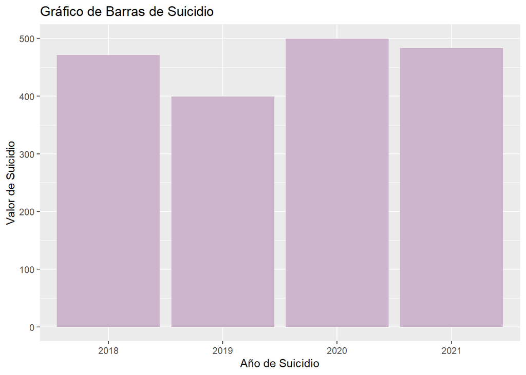

### Suicidio por comunidad autónoma

También hemos querido comparar los casos de suicidio en las distintas comunidades autónomas, y nos ha sorprendido la cantidad de casos de Galicia o incluso de Canarias.

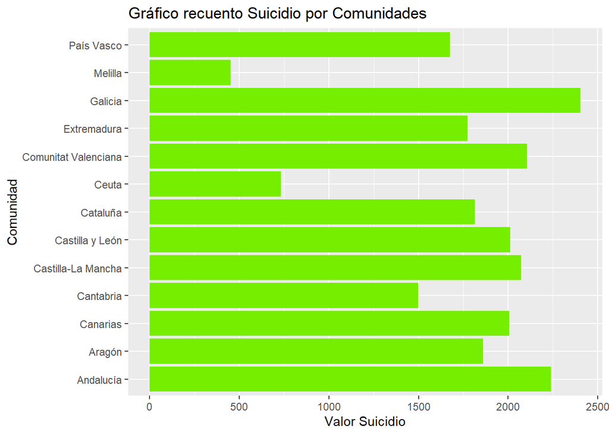

### Suicidio por rango de edad

Algo que también nos ha sorprendido y que hemos creido conveniente estudiar es el análisis de estos datos por edad. Creemos que los resultados de esta gráfica también respaldan nuestra hipótesis de que el ocio y tiempo libre influyen directamente en las enfermedades mentales y el suicidio, puesto que la tasa de suicidio más alta en España se da en personas mayores de entre 90 y 94 años, creemos que se el hecho de que se sientan solas o no acompañadas y el hecho de que, al estar jubilados tengan tanto tiempo libre pero no socializando, puede influir en estos datos. A su vez, creemos que un aumento de los casos de suicidio en este rango de edad se debe al suicidio aistido o eutanasia, ya que hay personas mayores que deben de permanecer en los hospitales de forma continua por su estado de salud y en numerosas ocasiones se recurre a este método para acabar con su sufrimiento.

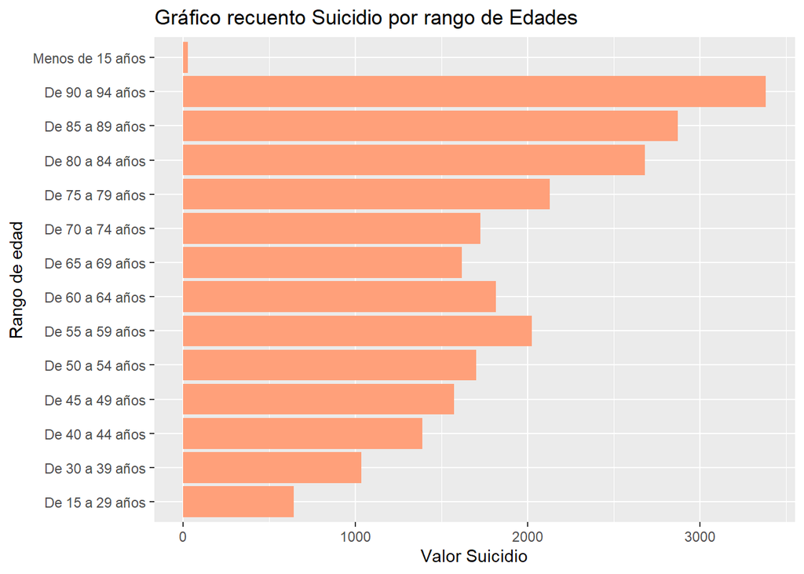

## Depresión

En segundo lugar, analizaremos la depresión en España. Iremos estudiando la depresión con sus distintas variables y posteriormente, la estudiaremos frente al suicidio para ver como estos datos se relacionan entre sí.

### Prevalencia de la depresión

En el caso de este conjunto, en la columna de “Prevalencia” hemos filtrado por aquellas celdas en las que se presente el transtorno, que consiste en los valores ” Cuadro depresivo mayor” y ” Otros cuadros depresivos”, ya que las otras posibles combinaciones eran “Sin cuadro depresivo” o “Total” y debemos de descartarlo porque nuestro interés es saber la relacion de aquellos que si que lo padecen.

```
## [1] " Cuadro depresivo mayor"      " Otros cuadros depresivos"
## [3] " Sin cuadro depresivo alguno" " TOTAL"
```

```
## # A tibble: 120 × 5
##    document.id Sexo_Depresion Prevalencia              Valor_Depresion Comunidad
##          <int> <chr>          <chr>                              <dbl> <chr>
##  1           2 Ambos sexos    " Cuadro depresivo mayo…            2.46 Total na…
##  2           3 Ambos sexos    " Otros cuadros depresi…            2.9  Total na…
##  3           6 Ambos sexos    " Cuadro depresivo mayo…            2.13 Andalucía
##  4           7 Ambos sexos    " Otros cuadros depresi…            1.75 Andalucía
##  5          10 Ambos sexos    " Cuadro depresivo mayo…            1.85 Aragón
##  6          11 Ambos sexos    " Otros cuadros depresi…            4.14 Aragón
##  7          14 Ambos sexos    " Cuadro depresivo mayo…            2.29 Asturias
##  8          15 Ambos sexos    " Otros cuadros depresi…            1.8  Asturias
##  9          18 Ambos sexos    " Cuadro depresivo mayo…            1.58 Balears
## 10          19 Ambos sexos    " Otros cuadros depresi…            2.14 Balears
## # ℹ 110 more rows
```

En esta gráfica podemos comprobar los distintos tipos de depresión:

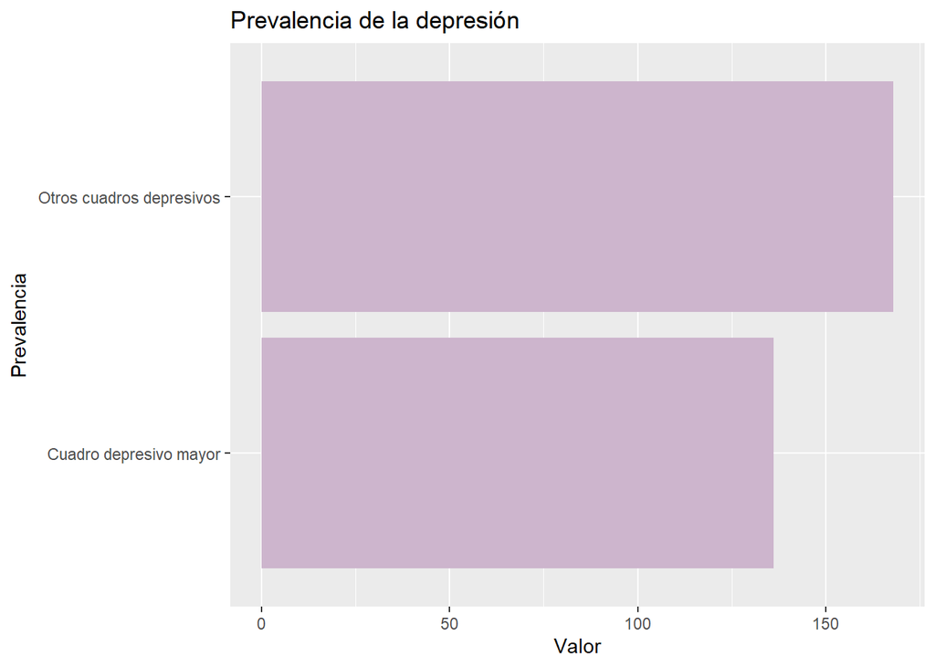

### Depresión y sexo

Hemos filtrado por “Hombres” y “Mujeres” porque la otra posible variable era “Total” e iba a ser redundante para el estudio.

```
## # A tibble: 80 × 5
##    document.id Sexo_Depresion Prevalencia              Valor_Depresion Comunidad
##          <int> <chr>          <chr>                              <dbl> <chr>
##  1          82 Hombres        " Cuadro depresivo mayo…            1.45 Total na…
##  2          83 Hombres        " Otros cuadros depresi…            2.03 Total na…
##  3          86 Hombres        " Cuadro depresivo mayo…            1.15 Andalucía
##  4          87 Hombres        " Otros cuadros depresi…            1.18 Andalucía
##  5          90 Hombres        " Cuadro depresivo mayo…            0.72 Aragón
##  6          91 Hombres        " Otros cuadros depresi…            2.68 Aragón
##  7          94 Hombres        " Cuadro depresivo mayo…            1.67 Asturias
##  8          95 Hombres        " Otros cuadros depresi…            0.55 Asturias
##  9          98 Hombres        " Cuadro depresivo mayo…            1.62 Balears
## 10          99 Hombres        " Otros cuadros depresi…            0.51 Balears
## # ℹ 70 more rows
```

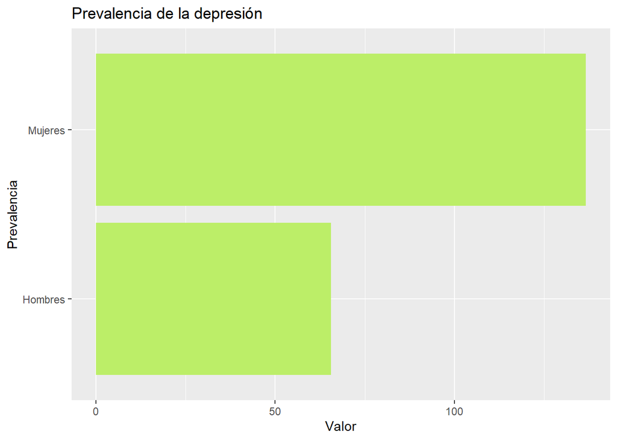

### Depresión por comunidad autónoma

En cuanto a la depresión por comunidades, esta sería la distribución:

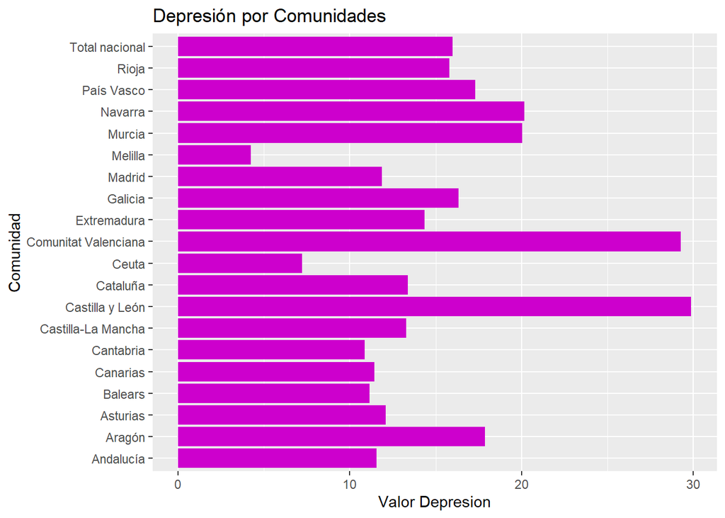

## CASO 1: Depresión y Suicidio en España

UNION DEPRESIÓN Y SUICIDIO El tratamiento de estos datos ha consistido en filtrar por el año en primer lugar, quedándonos sólo con el 2020. En cuanto al conjunto datos de depresión, de la varibale de prevalencia solo nos quedamos con los valores ” Cuadro depresivo mayor” y ” Otros cuadros depresivos”, porque las otras varibles son aquellos ciudadanos que no presentan este tipo de transtornos y el total, cosa que no nos interesa estudiar, porque queremos saber cuál es la relación con aquellos que si que padecen de depresión. Luego, se eliminan las filas duplicadas, se seleccionan ciertas columnas y se filtran las filas donde el valor de Comunidad no es “Total nacional”, porque queremos estudiar las comunidades por separado y el valor total sería redundante.

```
## [1] " Cuadro depresivo mayor"      " Otros cuadros depresivos"
## [3] " Sin cuadro depresivo alguno" " TOTAL"
```

```
## # A tibble: 120 × 5
##    document.id Sexo_Depresion Prevalencia              Valor_Depresion Comunidad
##          <int> <chr>          <chr>                              <dbl> <chr>
##  1           2 Ambos sexos    " Cuadro depresivo mayo…            2.46 Total na…
##  2           3 Ambos sexos    " Otros cuadros depresi…            2.9  Total na…
##  3           6 Ambos sexos    " Cuadro depresivo mayo…            2.13 Andalucía
##  4           7 Ambos sexos    " Otros cuadros depresi…            1.75 Andalucía
##  5          10 Ambos sexos    " Cuadro depresivo mayo…            1.85 Aragón
##  6          11 Ambos sexos    " Otros cuadros depresi…            4.14 Aragón
##  7          14 Ambos sexos    " Cuadro depresivo mayo…            2.29 Asturias
##  8          15 Ambos sexos    " Otros cuadros depresi…            1.8  Asturias
##  9          18 Ambos sexos    " Cuadro depresivo mayo…            1.58 Balears
## 10          19 Ambos sexos    " Otros cuadros depresi…            2.14 Balears
## # ℹ 110 more rows
```

```
## # A tibble: 14,112 × 10
##    document.id.x Sexo_Depresion Prevalencia            Valor_Depresion Comunidad
##            <int> <chr>          <chr>                            <dbl> <chr>
##  1             2 Ambos sexos    " Cuadro depresivo ma…            2.46 Total na…
##  2             2 Ambos sexos    " Cuadro depresivo ma…            2.46 Total na…
##  3             2 Ambos sexos    " Cuadro depresivo ma…            2.46 Total na…
##  4             2 Ambos sexos    " Cuadro depresivo ma…            2.46 Total na…
##  5             2 Ambos sexos    " Cuadro depresivo ma…            2.46 Total na…
##  6             2 Ambos sexos    " Cuadro depresivo ma…            2.46 Total na…
##  7             2 Ambos sexos    " Cuadro depresivo ma…            2.46 Total na…
##  8             2 Ambos sexos    " Cuadro depresivo ma…            2.46 Total na…
##  9             2 Ambos sexos    " Cuadro depresivo ma…            2.46 Total na…
## 10             2 Ambos sexos    " Cuadro depresivo ma…            2.46 Total na…
## # ℹ 14,102 more rows
## # ℹ 5 more variables: document.id.y <int>, Año_Suicidio <fct>,
## #   Edad_Suicidio <chr>, Sexo_Suicidio <chr>, Valor_Suicidio <dbl>
```

```
## # A tibble: 14,112 × 10
##    document.id.x Sexo_Depresion Prevalencia            Valor_Depresion Comunidad
##            <int> <chr>          <chr>                            <dbl> <chr>
##  1             2 Ambos sexos    " Cuadro depresivo ma…            2.46 Total na…
##  2             2 Ambos sexos    " Cuadro depresivo ma…            2.46 Total na…
##  3             2 Ambos sexos    " Cuadro depresivo ma…            2.46 Total na…
##  4             2 Ambos sexos    " Cuadro depresivo ma…            2.46 Total na…
##  5             2 Ambos sexos    " Cuadro depresivo ma…            2.46 Total na…
##  6             2 Ambos sexos    " Cuadro depresivo ma…            2.46 Total na…
##  7             2 Ambos sexos    " Cuadro depresivo ma…            2.46 Total na…
##  8             2 Ambos sexos    " Cuadro depresivo ma…            2.46 Total na…
##  9             2 Ambos sexos    " Cuadro depresivo ma…            2.46 Total na…
## 10             2 Ambos sexos    " Cuadro depresivo ma…            2.46 Total na…
## # ℹ 14,102 more rows
## # ℹ 5 more variables: document.id.y <int>, Año_Suicidio <fct>,
## #   Edad_Suicidio <chr>, Sexo_Suicidio <chr>, Valor_Suicidio <dbl>
```

```
## # A tibble: 13,104 × 5
##    Comunidad Sexo_Depresion Prevalencia           Valor_Depresion Valor_Suicidio
##    <chr>     <chr>          <chr>                           <dbl>          <dbl>
##  1 Andalucía Ambos sexos    " Cuadro depresivo m…            2.13          0.166
##  2 Andalucía Ambos sexos    " Cuadro depresivo m…            2.13          0.153
##  3 Andalucía Ambos sexos    " Cuadro depresivo m…            2.13          0
##  4 Andalucía Ambos sexos    " Cuadro depresivo m…            2.13          0.075
##  5 Andalucía Ambos sexos    " Cuadro depresivo m…            2.13          0.161
##  6 Andalucía Ambos sexos    " Cuadro depresivo m…            2.13          0
##  7 Andalucía Ambos sexos    " Cuadro depresivo m…            2.13          0
##  8 Andalucía Ambos sexos    " Cuadro depresivo m…            2.13          0.145
##  9 Andalucía Ambos sexos    " Cuadro depresivo m…            2.13          0.171
## 10 Andalucía Ambos sexos    " Cuadro depresivo m…            2.13          0.315
## # ℹ 13,094 more rows
```

```
## # A tibble: 13 × 3
##    Comunidad            vDepresion vSuicidio
##    <chr>                     <dbl>     <dbl>
##  1 Andalucía                 1.93      13.3
##  2 Aragón                    2.98      11.1
##  3 Canarias                  1.91      11.9
##  4 Cantabria                 1.81       8.93
##  5 Castilla y León           4.98      12.0
##  6 Castilla-La Mancha        2.21      12.3
##  7 Cataluña                  2.23      10.8
##  8 Ceuta                     1.20       4.37
##  9 Comunitat Valenciana      4.88      12.5
## 10 Extremadura               2.39      10.6
## 11 Galicia                   2.72      14.3
## 12 Melilla                   0.707      2.70
## 13 País Vasco                2.88       9.97
```

Este código agrupa los datos en depr_y_suicidio por la columna Comunidad y calcula la media de las columnas Valor_Depresion y Valor_Suicidio para cada grupo, almacenando los resultados en las columnas vDepresion y vSuicidio respectivamente. El resultado es un dataframe con la media de estas variables para cada comunidad.

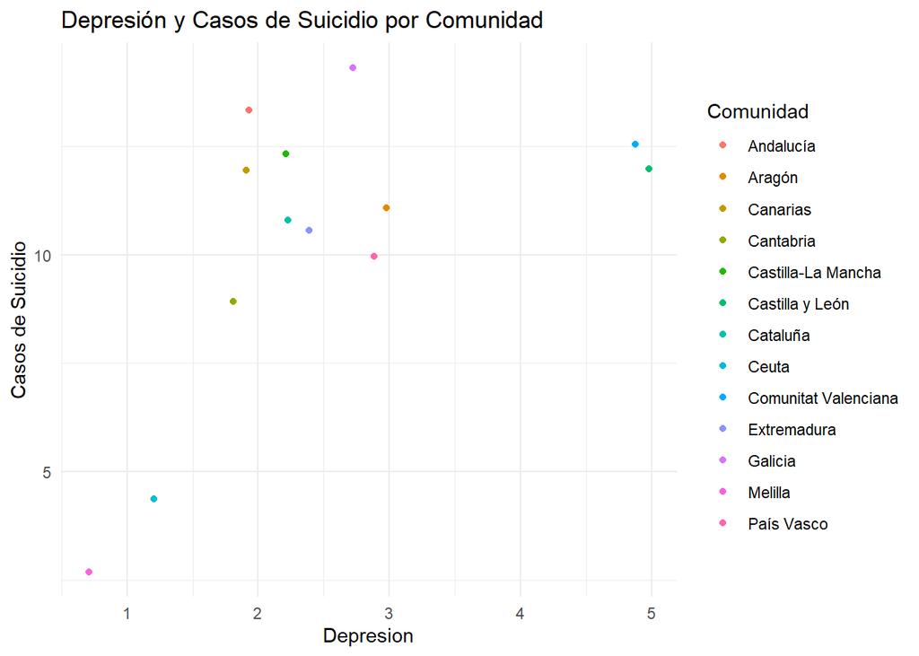

```
##  [1] "Andalucía"            "Aragón"               "Canarias"
##  [4] "Cantabria"            "Castilla-La Mancha"   "Castilla y León"
##  [7] "Cataluña"             "Ceuta"                "Comunitat Valenciana"
## [10] "Extremadura"          "Galicia"              "Melilla"
## [13] "País Vasco"
```

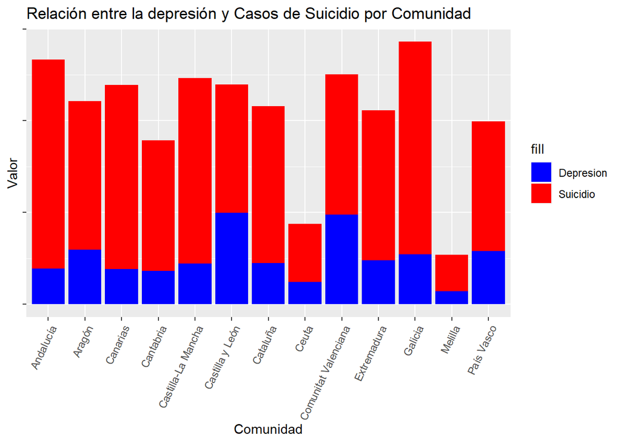

## CASO 2: Suicidio y PIB en España

UNION PIB Y SUICIDIO

En segundo lugar, como caso de estudio, vamos a analizar la relación entre el suicidio y el producto interior bruto de nuestro país, para ver si es una posible causa. Como hemos mencionado anteriormente, hemos tenido que utilizar .csv, ya que con JSON no era posible el estudio.

```
## # A tibble: 140 × 3
##    Comunidad      Periodo Total
##    <chr>            <dbl> <chr>
##  1 Total Nacional    2021 5,179
##  2 Total Nacional    2020 -11,291
##  3 Total Nacional    2019 1,269
##  4 Total Nacional    2018 1,86
##  5 Total Nacional    2017 2,79
##  6 Total Nacional    2016 2,943
##  7 Total Nacional    2015 3,936
##  8 Andalucía         2021 <NA>
##  9 Andalucía         2020 -10,381
## 10 Andalucía         2019 1,453
## # ℹ 130 more rows
```

Comprobamos los valores que se encuentan dentro de nuestro dataset PIB para ver si nos son todos de utilidad.Comprobamos los valores que se encuentan dentro de nuestro dataset PIB para ver si nos son todos de utilidad.

```
##  [1] "Andalucía"                   "Aragón"
##  [3] "Asturias, Principado de"     "Balears, Illes"
##  [5] "Canarias"                    "Cantabria"
##  [7] "Castilla - La Mancha"        "Castilla y León"
##  [9] "Cataluña"                    "Ceuta"
## [11] "Comunitat Valenciana"        "Extremadura"
## [13] "Galicia"                     "Madrid, Comunidad de"
## [15] "Melilla"                     "Murcia, Región de"
## [17] "Navarra, Comunidad Foral de" "País Vasco"
## [19] "Rioja, La"                   "Total Nacional"
```

```
##  [1] "Andalucía"            "Aragón"               "Canarias"
##  [4] "Cantabria"            "Castilla-La Mancha"   "Castilla y León"
##  [7] "Cataluña"             "Ceuta"                "Comunitat Valenciana"
## [10] "Extremadura"          "Galicia"              "Melilla"
## [13] "País Vasco"           "Total nacional"
```

```
## [1] "2015" "2016" "2017" "2018" "2019" "2020" "2021"
```

También modififcamos la columna de Comunidad para que tenga unos valores similares a los del dataset de Suicidio, y así poder unirlas mediante esta etiqueta.

Filtramos cada PIB por su año para poder compararlos.

```
## # A tibble: 20 × 3
##    Comunidad            Periodo Total
##    <chr>                  <dbl> <chr>
##  1 Total nacional          2020 -11,291
##  2 Andalucía               2020 -10,381
##  3 Aragón                  2020 -9,015
##  4 Asturias                2020 -9,839
##  5 Balears                 2020 -22,794
##  6 Canarias                2020 -18,956
##  7 Cantabria               2020 -9,826
##  8 Castilla y León         2020 -8,232
##  9 Castilla-La Mancha      2020 -8,085
## 10 Cataluña                2020 -12,071
## 11 Comunitat Valenciana    2020 -10,778
## 12 Extremadura             2020 -7,097
## 13 Galicia                 2020 -9,132
## 14 Madrid                  2020 -11,877
## 15 Murcia                  2020 -9,113
## 16 Navarra                 2020 -9,286
## 17 País Vasco              2020 -11,152
## 18 Rioja                   2020 -9,959
## 19 Ceuta                   2020 -8,549
## 20 Melilla                 2020 -8,933
```

```
## # A tibble: 20 × 3
##    Comunidad            Periodo Total
##    <chr>                  <dbl> <chr>
##  1 Total nacional          2019 1,269
##  2 Andalucía               2019 1,453
##  3 Aragón                  2019 0,42
##  4 Asturias                2019 1,78
##  5 Balears                 2019 1,002
##  6 Canarias                2019 1,061
##  7 Cantabria               2019 1,314
##  8 Castilla y León         2019 1,119
##  9 Castilla-La Mancha      2019 0,48
## 10 Cataluña                2019 0,818
## 11 Comunitat Valenciana    2019 0,943
## 12 Extremadura             2019 2,254
## 13 Galicia                 2019 1,643
## 14 Madrid                  2019 1,565
## 15 Murcia                  2019 1,147
## 16 Navarra                 2019 1,443
## 17 País Vasco              2019 1,155
## 18 Rioja                   2019 1,019
## 19 Ceuta                   2019 1,563
## 20 Melilla                 2019 1,699
```

```
## # A tibble: 20 × 3
##    Comunidad            Periodo Total
##    <chr>                  <dbl> <chr>
##  1 Total nacional          2018 1,86
##  2 Andalucía               2018 2,526
##  3 Aragón                  2018 2,643
##  4 Asturias                2018 2,051
##  5 Balears                 2018 1,199
##  6 Canarias                2018 0,964
##  7 Cantabria               2018 2,078
##  8 Castilla y León         2018 3,446
##  9 Castilla-La Mancha      2018 3,277
## 10 Cataluña                2018 1,164
## 11 Comunitat Valenciana    2018 1,697
## 12 Extremadura             2018 2,401
## 13 Galicia                 2018 2,234
## 14 Madrid                  2018 1,433
## 15 Murcia                  2018 -0,41
## 16 Navarra                 2018 0,998
## 17 País Vasco              2018 1,736
## 18 Rioja                   2018 1,902
## 19 Ceuta                   2018 2,084
## 20 Melilla                 2018 2,438
```

```
##  [1] "Andalucía"            "Aragón"               "Asturias"
##  [4] "Balears"              "Canarias"             "Cantabria"
##  [7] "Castilla-La Mancha"   "Castilla y León"      "Cataluña"
## [10] "Ceuta"                "Comunitat Valenciana" "Extremadura"
## [13] "Galicia"              "Madrid"               "Melilla"
## [16] "Murcia"               "Navarra"              "País Vasco"
## [19] "Rioja"                "Total nacional"
```

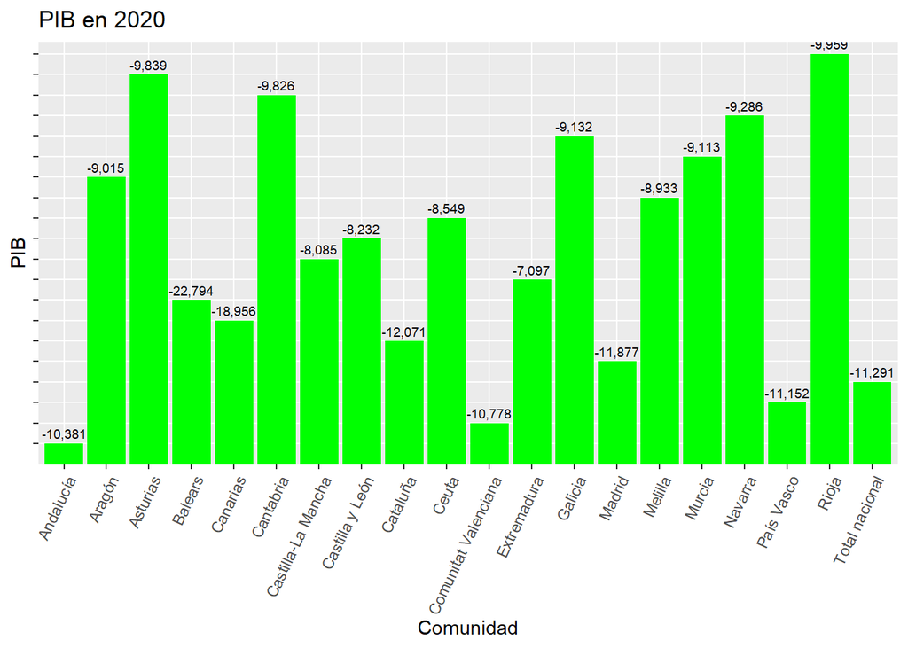

El PIB máximo en 2019 fue de 2.254 y el mínimo de 0.42.

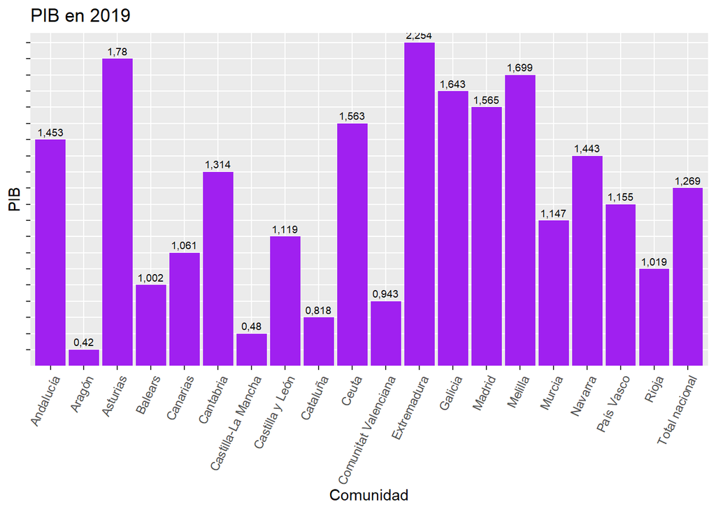

En 2018, el PIB máximo fue de 3.446 y el mínimo de -0.41.

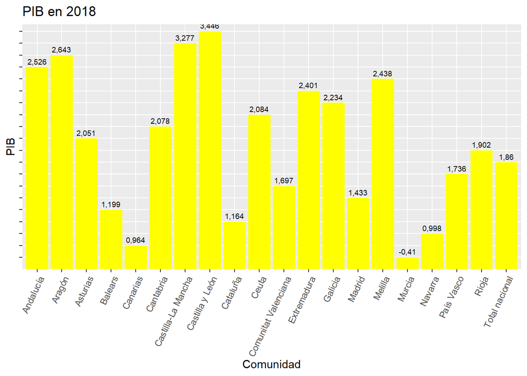

Si comparamos los datos de la tabla oiginal PIB y los de los años que nos interesan (interpretando también sus graficas), podemos ver como el producto interior bruto de cada Comunidad Autonoma se mantenia en un constante crecimiento o disminuía ligeramente ,pero en 2020, a causa de la pandemia, este PIB cayó en picado debido a la crisis inseperada que sufrimos por esa situación. Hay que tener en cuenta que los valores muestran el porcentaje de crecimiento y decrecimiento que sufrió cada CCAA en relación a PIB.

```
##  [1] "Andalucía"            "Aragón"               "Asturias"
##  [4] "Balears"              "Canarias"             "Cantabria"
##  [7] "Castilla-La Mancha"   "Castilla y León"      "Cataluña"
## [10] "Ceuta"                "Comunitat Valenciana" "Extremadura"
## [13] "Galicia"              "Madrid"               "Melilla"
## [16] "Murcia"               "Navarra"              "País Vasco"
## [19] "Rioja"                "Total nacional"
```

```
##  [1] "Andalucía"            "Aragón"               "Canarias"
##  [4] "Cantabria"            "Castilla-La Mancha"   "Castilla y León"
##  [7] "Cataluña"             "Ceuta"                "Comunitat Valenciana"
## [10] "Extremadura"          "Galicia"              "Melilla"
## [13] "País Vasco"           "Total nacional"
```

```
## # A tibble: 594 × 8
##    document.id Año_Suicidio Comunidad Edad_Suicidio Sexo_Suicidio Valor_Suicidio
##          <int> <fct>        <chr>     <chr>         <chr>                  <dbl>
##  1           1 2020         Total na… " Menos de 1… " Total"               0.206
##  2           2 2020         Total na… " Menos de 1… " Hombres"             0.199
##  3           3 2020         Total na… " Menos de 1… " Mujeres"             0.212
##  4           4 2020         Total na… " De 15 a 29… " Total"               4.09
##  5           5 2020         Total na… " De 15 a 29… " Hombres"             6.05
##  6           6 2020         Total na… " De 15 a 29… " Mujeres"             2.04
##  7           7 2020         Total na… " De 30 a 39… " Total"               6.82
##  8           8 2020         Total na… " De 30 a 39… " Hombres"            10.4
##  9           9 2020         Total na… " De 30 a 39… " Mujeres"             3.24
## 10          10 2020         Total na… " De 40 a 44… " Total"               9.13
## # ℹ 584 more rows
## # ℹ 2 more variables: Periodo <dbl>, Total <chr>
```

```
## # A tibble: 594 × 3
## # Groups:   Comunidad [20]
##    Comunidad vSicidio Total
##    <chr>        <dbl> <chr>
##  1 Andalucía     14.8 -10,381
##  2 Andalucía     14.8 -10,381
##  3 Andalucía     14.8 -10,381
##  4 Andalucía     14.8 -10,381
##  5 Andalucía     14.8 -10,381
##  6 Andalucía     14.8 -10,381
##  7 Andalucía     14.8 -10,381
##  8 Andalucía     14.8 -10,381
##  9 Andalucía     14.8 -10,381
## 10 Andalucía     14.8 -10,381
## # ℹ 584 more rows
```

```
## # A tibble: 594 × 8
##    document.id Año_Suicidio Comunidad Edad_Suicidio Sexo_Suicidio Valor_Suicidio
##          <int> <fct>        <chr>     <chr>         <chr>                  <dbl>
##  1           1 2018         Total na… " Menos de 1… " Total"               0.101
##  2           2 2018         Total na… " Menos de 1… " Hombres"             0.112
##  3           3 2018         Total na… " Menos de 1… " Mujeres"             0.089
##  4           4 2018         Total na… " De 15 a 29… " Total"               3.79
##  5           5 2018         Total na… " De 15 a 29… " Hombres"             5.63
##  6           6 2018         Total na… " De 15 a 29… " Mujeres"             1.87
##  7           7 2018         Total na… " De 30 a 39… " Total"               6.26
##  8           8 2018         Total na… " De 30 a 39… " Hombres"             9.78
##  9           9 2018         Total na… " De 30 a 39… " Mujeres"             2.75
## 10          10 2018         Total na… " De 40 a 44… " Total"               7.92
## # ℹ 584 more rows
## # ℹ 2 more variables: Periodo <dbl>, Total <chr>
```

```
## # A tibble: 594 × 3
## # Groups:   Comunidad [20]
##    Comunidad vSuicidio Total
##    <chr>         <dbl> <chr>
##  1 Andalucía      11.8 2,526
##  2 Andalucía      11.8 2,526
##  3 Andalucía      11.8 2,526
##  4 Andalucía      11.8 2,526
##  5 Andalucía      11.8 2,526
##  6 Andalucía      11.8 2,526
##  7 Andalucía      11.8 2,526
##  8 Andalucía      11.8 2,526
##  9 Andalucía      11.8 2,526
## 10 Andalucía      11.8 2,526
## # ℹ 584 more rows
```

```
## # A tibble: 594 × 8
##    document.id Año_Suicidio Comunidad Edad_Suicidio Sexo_Suicidio Valor_Suicidio
##          <int> <fct>        <chr>     <chr>         <chr>                  <dbl>
##  1           1 2019         Total na… " Menos de 1… " Total"               0.102
##  2           2 2019         Total na… " Menos de 1… " Hombres"             0.113
##  3           3 2019         Total na… " Menos de 1… " Mujeres"             0.09
##  4           4 2019         Total na… " De 15 a 29… " Total"               4.28
##  5           5 2019         Total na… " De 15 a 29… " Hombres"             6.38
##  6           6 2019         Total na… " De 15 a 29… " Mujeres"             2.10
##  7           7 2019         Total na… " De 30 a 39… " Total"               6.70
##  8           8 2019         Total na… " De 30 a 39… " Hombres"            10.2
##  9           9 2019         Total na… " De 30 a 39… " Mujeres"             3.20
## 10          10 2019         Total na… " De 40 a 44… " Total"               8.62
## # ℹ 584 more rows
## # ℹ 2 more variables: Periodo <dbl>, Total <chr>
```

```
## # A tibble: 594 × 3
## # Groups:   Comunidad [20]
##    Comunidad vSuicidio Total
##    <chr>         <dbl> <chr>
##  1 Andalucía      11.3 1,453
##  2 Andalucía      11.3 1,453
##  3 Andalucía      11.3 1,453
##  4 Andalucía      11.3 1,453
##  5 Andalucía      11.3 1,453
##  6 Andalucía      11.3 1,453
##  7 Andalucía      11.3 1,453
##  8 Andalucía      11.3 1,453
##  9 Andalucía      11.3 1,453
## 10 Andalucía      11.3 1,453
## # ℹ 584 more rows
```

```
##  [1] "Andalucía"            "Aragón"               "Asturias"
##  [4] "Balears"              "Canarias"             "Cantabria"
##  [7] "Castilla-La Mancha"   "Castilla y León"      "Cataluña"
## [10] "Ceuta"                "Comunitat Valenciana" "Extremadura"
## [13] "Galicia"              "Madrid"               "Melilla"
## [16] "Murcia"               "Navarra"              "País Vasco"
## [19] "Rioja"                "Total nacional"
```

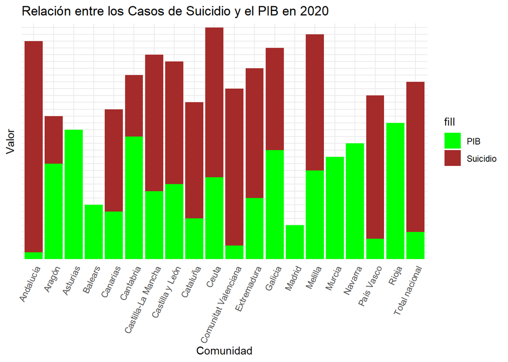

```
##  [1] "Andalucía"            "Aragón"               "Asturias"
##  [4] "Balears"              "Canarias"             "Cantabria"
##  [7] "Castilla-La Mancha"   "Castilla y León"      "Cataluña"
## [10] "Ceuta"                "Comunitat Valenciana" "Extremadura"
## [13] "Galicia"              "Madrid"               "Melilla"
## [16] "Murcia"               "Navarra"              "País Vasco"
## [19] "Rioja"                "Total nacional"
```

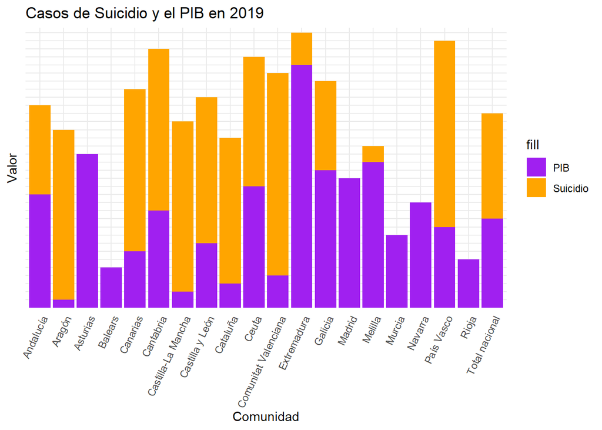

```
##  [1] "Andalucía"            "Aragón"               "Asturias"
##  [4] "Balears"              "Canarias"             "Cantabria"
##  [7] "Castilla-La Mancha"   "Castilla y León"      "Cataluña"
## [10] "Ceuta"                "Comunitat Valenciana" "Extremadura"
## [13] "Galicia"              "Madrid"               "Melilla"
## [16] "Murcia"               "Navarra"              "País Vasco"
## [19] "Rioja"                "Total nacional"
```

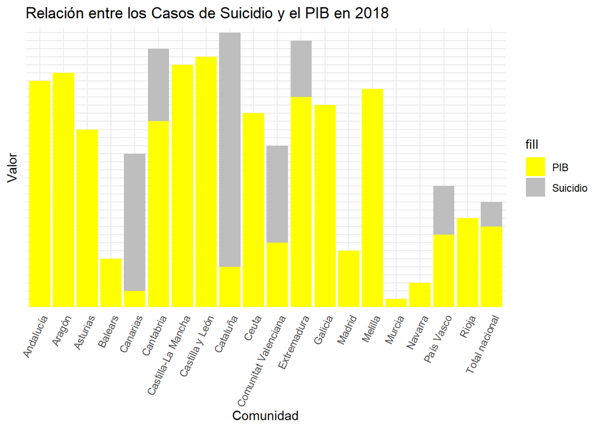

Antes de iniciar el planteamiento de los resultados, me gustaria comentar porque hay columnas en las graficas que solo tienen un color. Esto no se debe a que el valor del PIB solape a los valores de suicidio, sino que hay 6 comunidades auntonomas que a la hora de calcular su media de casos de suicidio nos devolvieron valores NAs, estas comunidades son Asturias, Balears, Madrid, Murcia, Navarra y Rioja. En el caso de la última gráfica, la de 2018, podemos ver como hay alguna columna más que solo presenta un único color, esto se debe a un problema a la hora de graficar, y no de datos, ya que si revisamos la tabla de datos de la que sacamos dicha grafica comunidades por ejemplo como Andalucía o Castilla y León si presentan valores para suicidio.

Ahora bien, si comaparamos los resultados obtenidos a la hora de cruzar los datos del Producto Interior Bruto y de Casos de Suicidio por Comunidad Autónoma, podemos observar en cualquiera de los años que estudiamos, como no hay ninguna relación aparente entre estas dos variables estudiadas; de la misma forma, si comaparamos los 3 años y nos fijamos en si las barras de cada comunudad sigue un patrón relacional que no ayude a formular alguna relación, podemos apreciar como en cada año toman valores diferentes, por lo que hemos concluido que no hay relación entre las varibles PIB y Tasa de Suicidio por Comunidad Autónoma, al igual que no existe relación entre la variación del PIB con el paso de los años y el aumento o descenso de los casos de suicidio, por lo tanto el PIB nos esta asociado con la variable Suicidio.

## CASO 3: Depresión y PIB

```
## tibble [60 × 3] (S3: tbl_df/tbl/data.frame)
##  $ Comunidad: chr [1:60] "Total nacional" "Total nacional" "Total nacional" "Andalucía" ...
##  $ Periodo  : num [1:60] 2020 2019 2018 2020 2019 ...
##  $ Total    : chr [1:60] "-11,291" "1,269" "1,86" "-10,381" ...
```

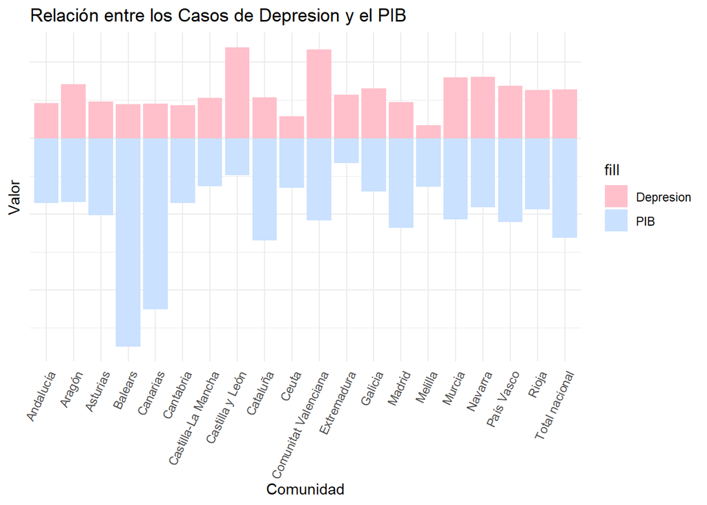

```
##  [1] "Andalucía"            "Aragón"               "Asturias"
##  [4] "Balears"              "Canarias"             "Cantabria"
##  [7] "Castilla-La Mancha"   "Castilla y León"      "Cataluña"
## [10] "Ceuta"                "Comunitat Valenciana" "Extremadura"
## [13] "Galicia"              "Madrid"               "Melilla"
## [16] "Murcia"               "Navarra"              "País Vasco"
## [19] "Rioja"                "Total nacional"
```

```
##  [1] "Andalucía"                   "Aragón"
##  [3] "Asturias, Principado de"     "Balears, Illes"
##  [5] "Canarias"                    "Cantabria"
##  [7] "Castilla - La Mancha"        "Castilla y León"
##  [9] "Cataluña"                    "Ceuta"
## [11] "Comunitat Valenciana"        "Extremadura"
## [13] "Galicia"                     "Madrid, Comunidad de"
## [15] "Melilla"                     "Murcia, Región de"
## [17] "Navarra, Comunidad Foral de" "País Vasco"
## [19] "Rioja, La"                   "Total Nacional"
```

```
## [1] "2018" "2019" "2020" "2021"
```

```
## [1] "tbl_df"     "tbl"        "data.frame"
```

```
## [1] "tbl_df"     "tbl"        "data.frame"
```

```
## [1] "Periodo"   "Total"     "Comunidad"
```

```
## [1] "document.id"    "Año_Suicidio"   "Comunidad"      "Edad_Suicidio"
## [5] "Sexo_Suicidio"  "Valor_Suicidio"
```